# Wine

Anurag

January 24, 2017

Exploring White Wine Quality:

# Data Loading

Now we have to Load the data

Now the data is loaded into the wine variable which contains 4898 observations and 13 variables. The data contains the chemical properties of different white wines available. I will explore a data set on wine quality and physicochemical properties. The objective is to explore which chemical properties influence the quality of white wines. The relationship will be statistically defined and will be illustrated using various plots.

# Summary of Data:

Here we will summarize our data to find the properties:

```r
str(wine)
```

```
## 'data.frame':    4898 obs. of  13 variables:
##  $ X                   : int  1 2 3 4 5 6 7 8 9 10 ...
##  $ fixed.acidity       : num  7 6.3 8.1 7.2 7.2 8.1 6.2 7 6.3 8.1 ...
##  $ volatile.acidity    : num  0.27 0.3 0.28 0.23 0.23 0.28 0.32 0.27 0.3 0.22 ...
##  $ citric.acid         : num  0.36 0.34 0.4 0.32 0.32 0.4 0.16 0.36 0.34 0.43 ...
##  $ residual.sugar      : num  20.7 1.6 6.9 8.5 8.5 6.9 7 20.7 1.6 1.5 ...
##  $ chlorides           : num  0.045 0.049 0.05 0.058 0.058 0.05 0.045 0.045 0.049 0.044 ...
##  $ free.sulfur.dioxide : num  45 14 30 47 47 30 30 45 14 28 ...
##  $ total.sulfur.dioxide: num  170 132 97 186 186 97 136 170 132 129 ...
##  $ density             : num  1.001 0.994 0.995 0.996 0.996 ...
##  $ pH                  : num  3 3.3 3.26 3.19 3.19 3.26 3.18 3 3.3 3.22 ...
##  $ sulphates           : num  0.45 0.49 0.44 0.4 0.4 0.44 0.47 0.45 0.49 0.45 ...
##  $ alcohol             : num  8.8 9.5 10.1 9.9 9.9 10.1 9.6 8.8 9.5 11 ...
##  $ quality             : int  6 6 6 6 6 6 6 6 6 6 ...
```

```r
summary(wine)
```

```
##        X        fixed.acidity    volatile.acidity  citric.acid
##  Min.   :   1   Min.   : 3.800   Min.   :0.0800   Min.   :0.0000
##  1st Qu.:1225   1st Qu.: 6.300   1st Qu.:0.2100   1st Qu.:0.2700
##  Median :2450   Median : 6.800   Median :0.2600   Median :0.3200
##  Mean   :2450   Mean   : 6.855   Mean   :0.2782   Mean   :0.3342
##  3rd Qu.:3674   3rd Qu.: 7.300   3rd Qu.:0.3200   3rd Qu.:0.3900
##  Max.   :4898   Max.   :14.200   Max.   :1.1000   Max.   :1.6600
##  residual.sugar     chlorides       free.sulfur.dioxide
##  Min.   : 0.600   Min.   :0.00900   Min.   :  2.00
##  1st Qu.: 1.700   1st Qu.:0.03600   1st Qu.: 23.00
##  Median : 5.200   Median :0.04300   Median : 34.00
##  Mean   : 6.391   Mean   :0.04577   Mean   : 35.31
##  3rd Qu.: 9.900   3rd Qu.:0.05000   3rd Qu.: 46.00
##  Max.   :65.800   Max.   :0.34600   Max.   :289.00
##  total.sulfur.dioxide    density             pH          sulphates
##  Min.   :  9.0        Min.   :0.9871   Min.   :2.720   Min.   :0.2200
##  1st Qu.:108.0        1st Qu.:0.9917   1st Qu.:3.090   1st Qu.:0.4100
##  Median :134.0        Median :0.9937   Median :3.180   Median :0.4700
##  Mean   :138.4        Mean   :0.9940   Mean   :3.188   Mean   :0.4898
##  3rd Qu.:167.0        3rd Qu.:0.9961   3rd Qu.:3.280   3rd Qu.:0.5500
##  Max.   :440.0        Max.   :1.0390   Max.   :3.820   Max.   :1.0800
##     alcohol         quality
##  Min.   : 8.00   Min.   :3.000
##  1st Qu.: 9.50   1st Qu.:5.000
##  Median :10.40   Median :6.000
##  Mean   :10.51   Mean   :5.878
##  3rd Qu.:11.40   3rd Qu.:6.000
##  Max.   :14.20   Max.   :9.000
```

From the above output we can make the following observations: 1. X is the primary key for the data 2. There are 4898 observations 3. The quality of wine ranges from 3 to 9. 4. the variable ‘residual.sugar’ contains an outlier 65.8 which is much great than its third quadrant value. 5. There are dependent variable like fixed and volatile acidity, free sulfur dioxide and total sulfur dioxide.

Since the main focus is the quality, let’s explore the quality variable.

```r
summary(wine$quality)
```

```
##    Min. 1st Qu.  Median    Mean 3rd Qu.    Max.
##   3.000   5.000   6.000   5.878   6.000   9.000
```

As observed the range of wine quality varies from 3 to 9 and the mean and the median are approximately same.

Since the data is factored we will now plot the data to find the relationships

# Single Variable Plots:

To first explore this data visually with the help of histogram on all the variables

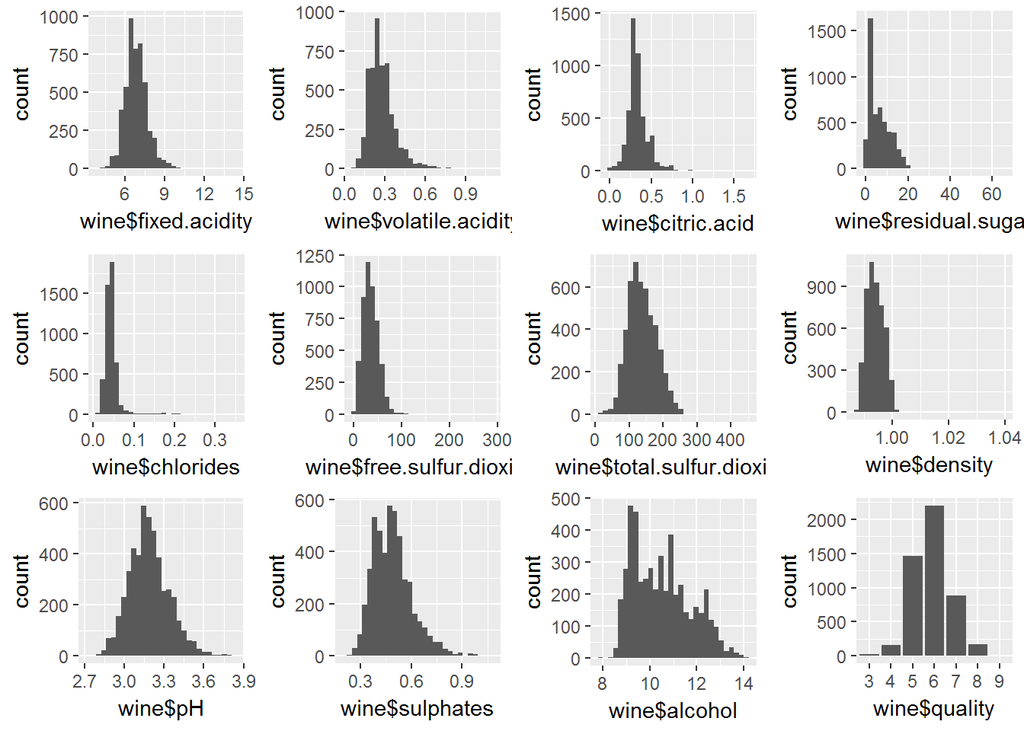

# Single Variable Plot Analysis:

## Wine Analysis:

As observed from the above histogram we can see that the major quality of wine lies with 5 to 7 and the factor 6 has the highest distribution.

```
##     bad average    good
##     183    3655    1060
```

we can see that only 183 samples are of bad wines and the highest samples are of average quality wine.

Now let us plot the graph to see it visually.

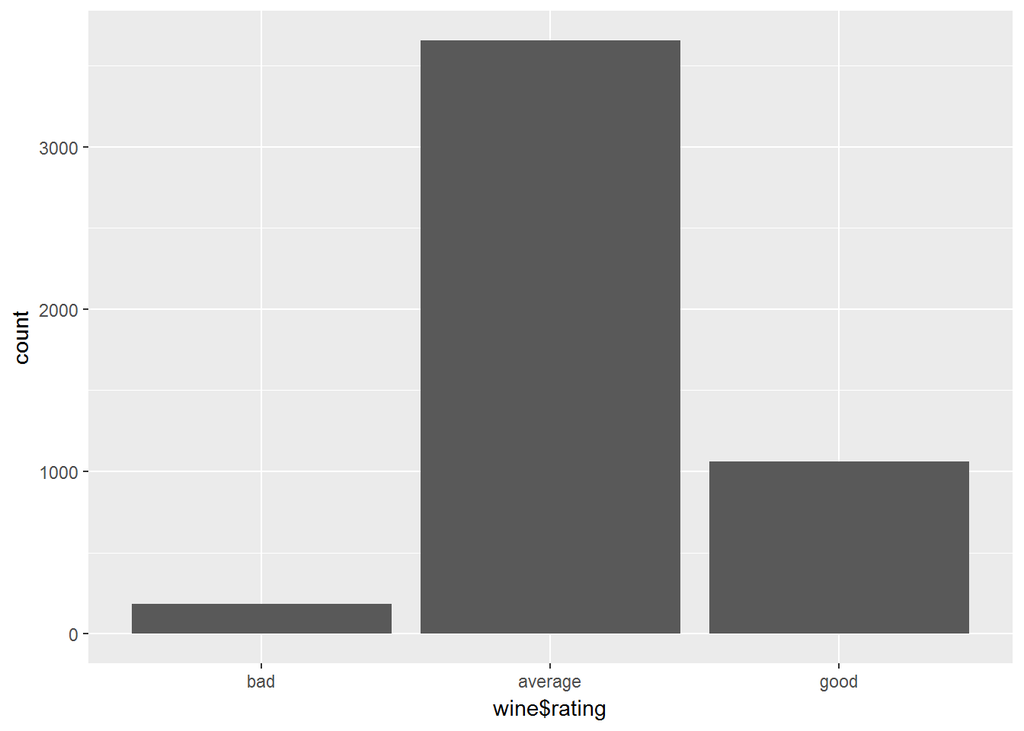

# Outliers:

We can observe that the ‘pH’ table is normalized whereas Fixed and volatile acidity, sulfur dioxides, sulfates, and density seem to be long-tailed. Residual sugar and chlorides have extreme outliers. Lastly we can observe a lot of “0” values in citric acid.

Let us try plotting the graphs with log10. we will first plot the two values of long tail and citric acid to visualize the output.

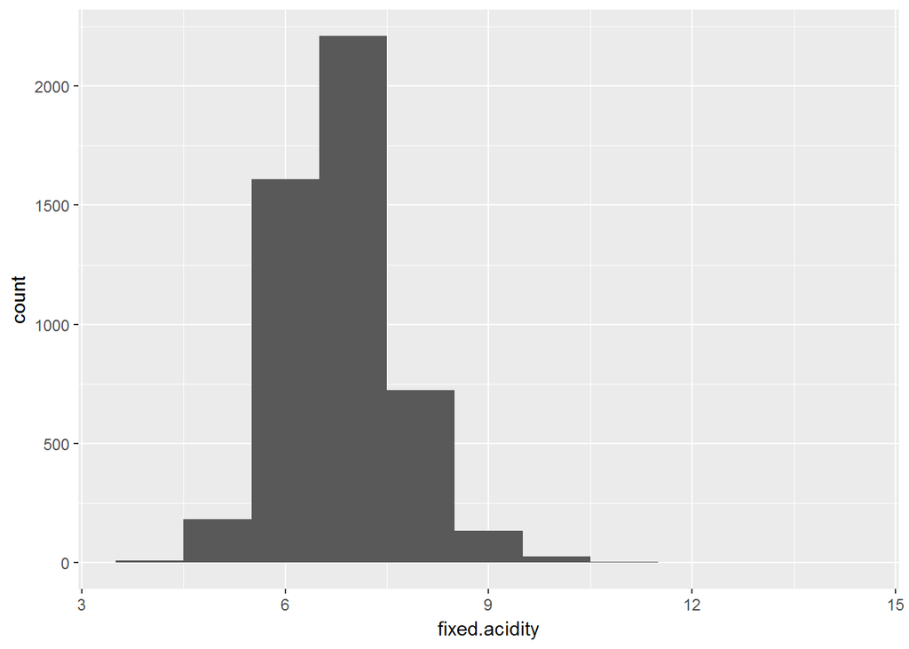

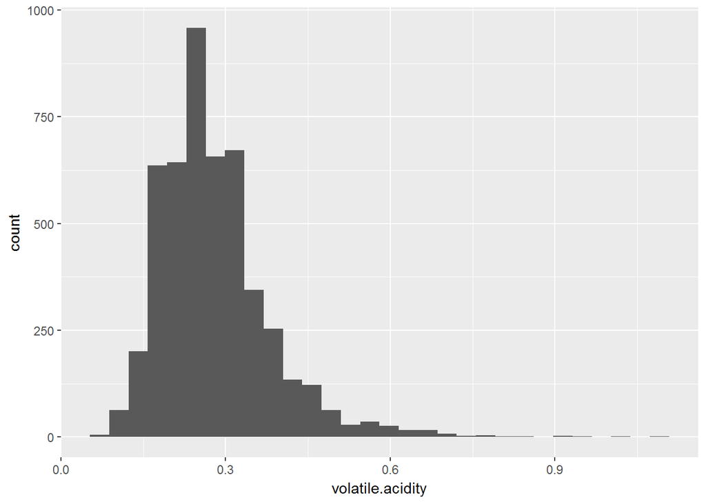

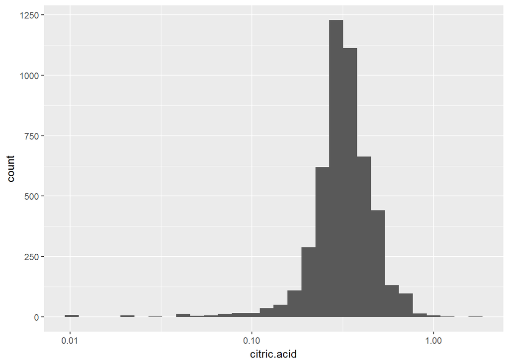

```r
length(subset(wine, citric.acid == 0)$citric.acid)
```

```
## [1] 19
```

19 values of the citric acid are 0, which cannot be ignored.

Now we will plot the remaining graphs 1st is of residual sugar, since it contains outliers only 95Th percentile is shown and lastly the values are converted to log10, similar processing is done with all the left values.

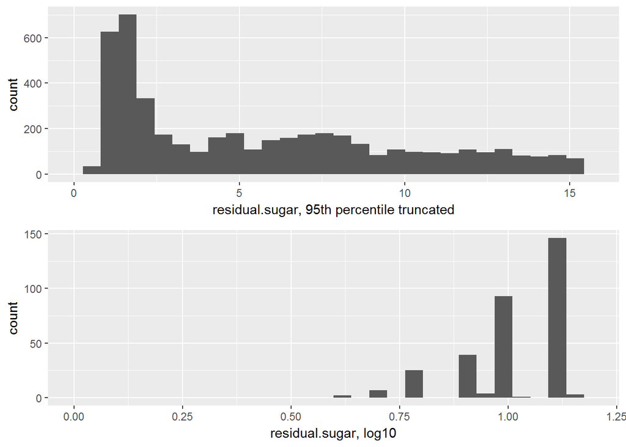

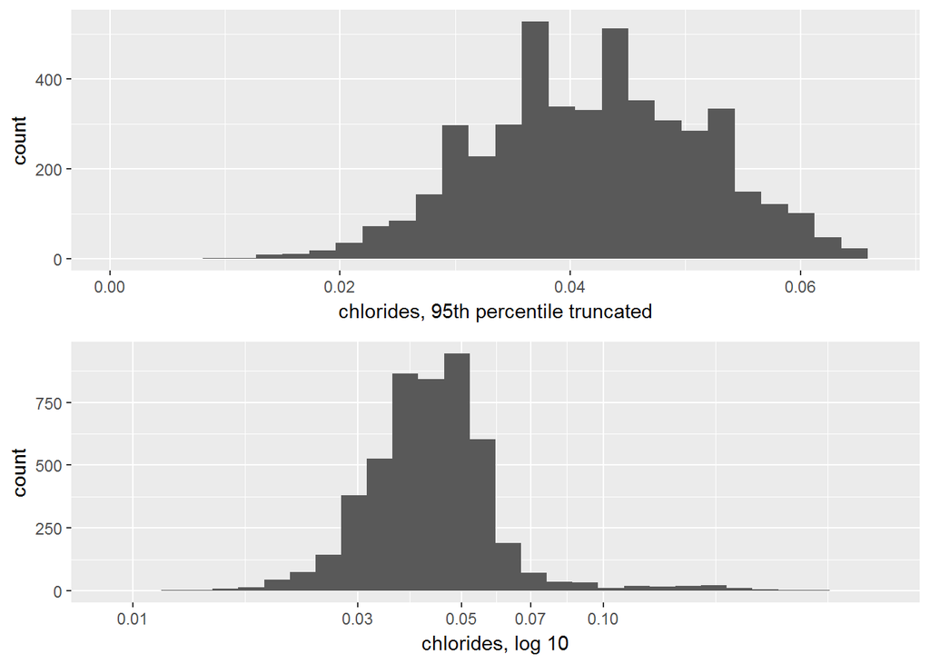

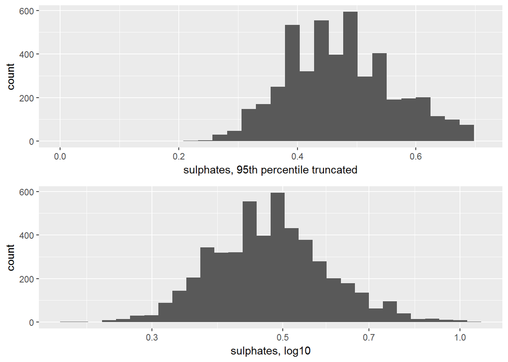

### Short questions

#### What other features in the dataset do you think will help support your investigation into your feature(s) of interest?

while studying i find that acids plays an important role in alcohol. Acids are present in grapes, acids are added while preparing as well as storing the wines. The pH value 2.9 to 3.9 are apt for good wines. As the acids influences on the color, balance and taste of the wine as well as the growth and vitality of yeast during fermentation and protecting the wine from bacteria. Apart from acids the wines are categorized in various forms which will help in knowing the composition by category. Categories could be Sweet wine or dry wine. The sweet wines contains high residual sugar whereas the sugar content of dry wine is very less. #### Did you create any new variables from existing variables in the dataset?

yes i created two values one is the rating, second is of the total acid in the wine which is shown as follows: The ACID.acidity contains all the acid information available with us (i.e. Citric acid, Fixed acid and volatile acid).

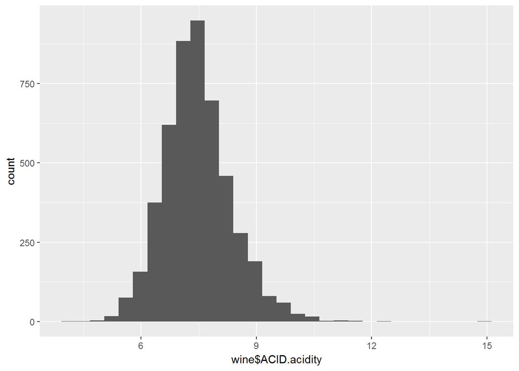

#### Of the features you investigated, were there any unusual distributions? Did you perform any operations on the data to tidy, adjust, or change the form of the data? If so, why did you do this?

yes outliers are present in variables. the best method to find outlier is the box plot methods, therefore here i will plot the variables in box plot format to find outliers.

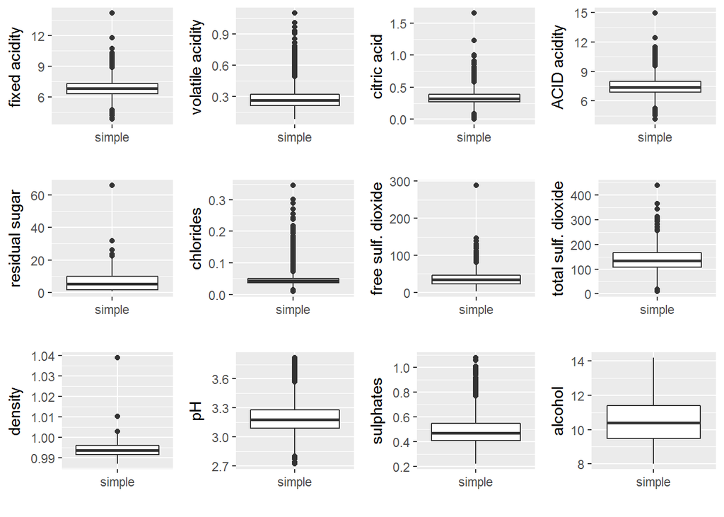

## Two variable Plots and Analysis:

First of all let us plot the box plot with two variable to analyze the dependency of the variables.

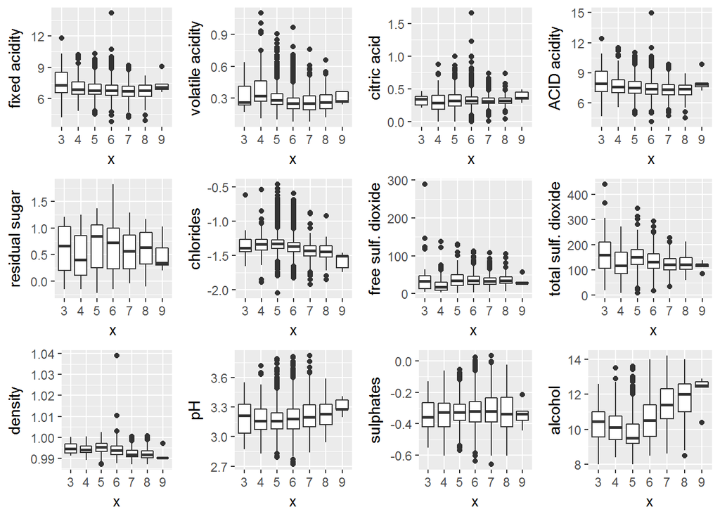

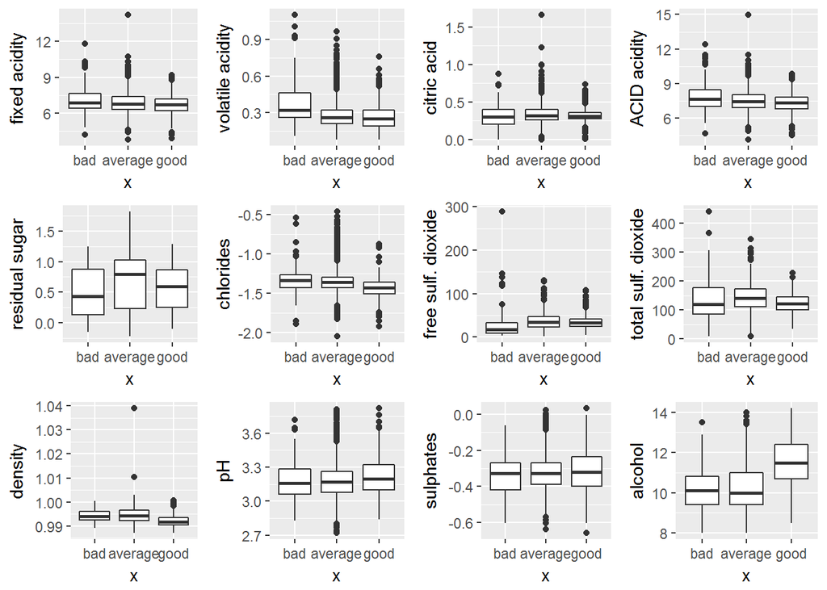

Residual sugar and sulfur dioxides did not seem to have a dramatic impact on the quality or rating of the wines. Interestingly, it appears that different types of acid affect wine quality different; as such, Total acidity i.e. ACID.acidity saw an attenuated trend, as the presence of volatile (acetic) acid accompanied decreased quality.

By utilizing cor.test function, I calculated the correlation for each of these variables against quality:

```
##        fixed.acidity     volatile.acidity          citric.acid
##         -0.113662831         -0.194722969         -0.009209091
##         ACID.acidity log10.residual.sugar      log10.chlordies
##         -0.131377207         -0.064631762         -0.272856661
##  free.sulfur.dioxide total.sulfur.dioxide              density
##          0.008158067         -0.174737218         -0.307123313
##                   pH      log10.sulphates              alcohol
##          0.099427246          0.037766168          0.435574715
```

Now we will plot the variable against each other:

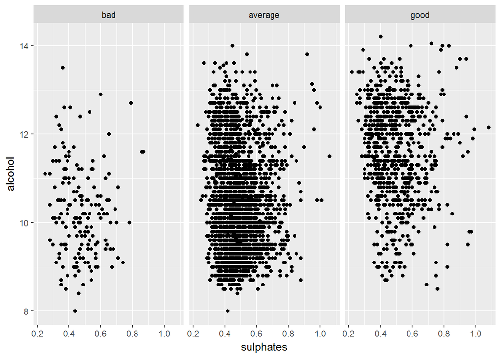

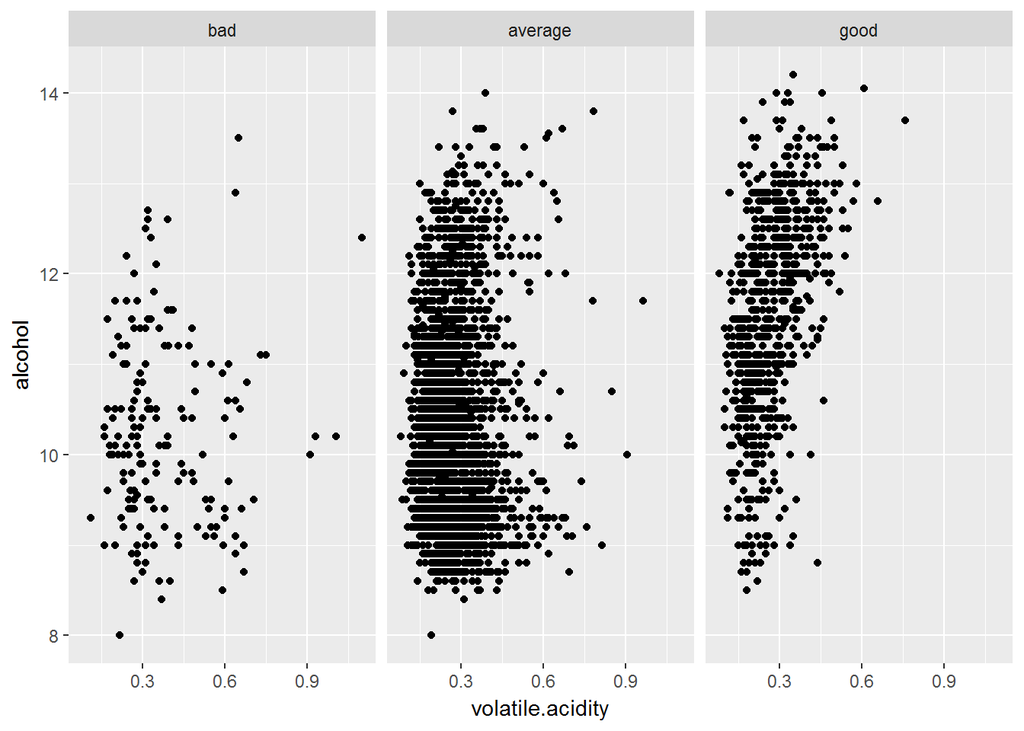

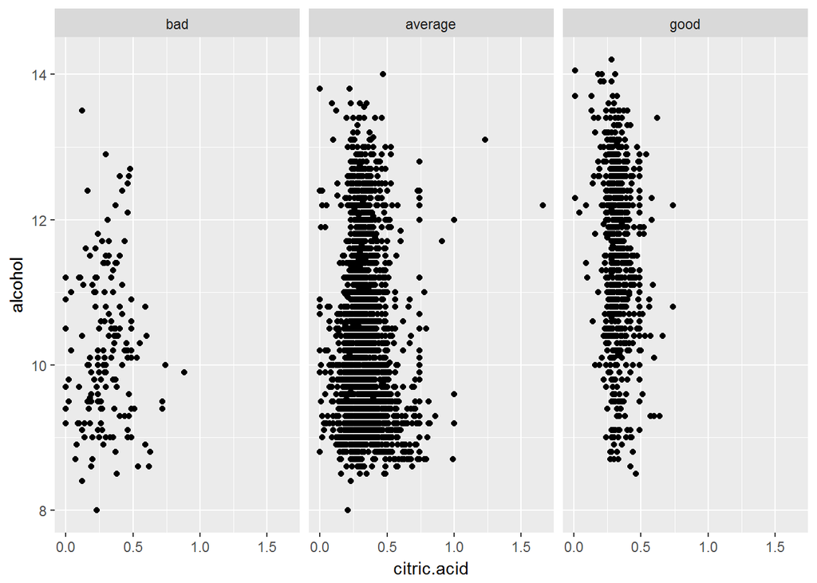

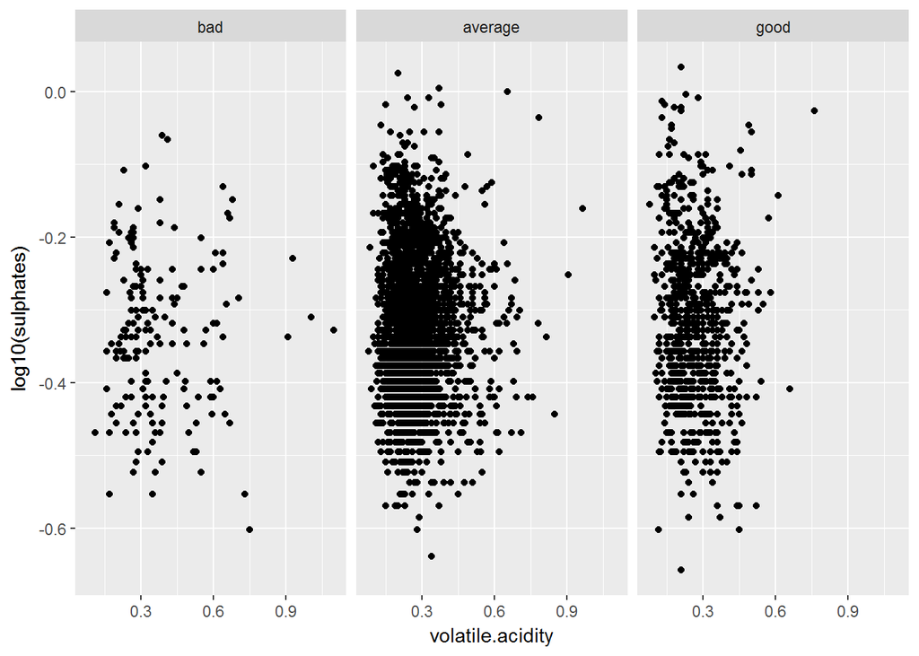

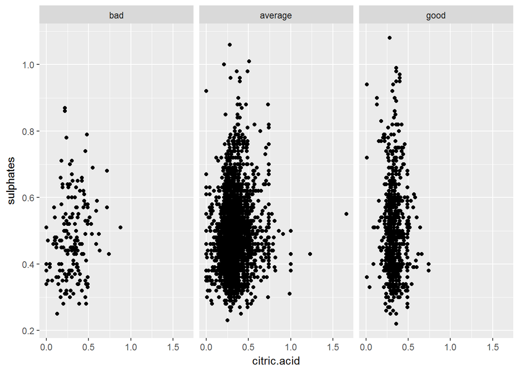

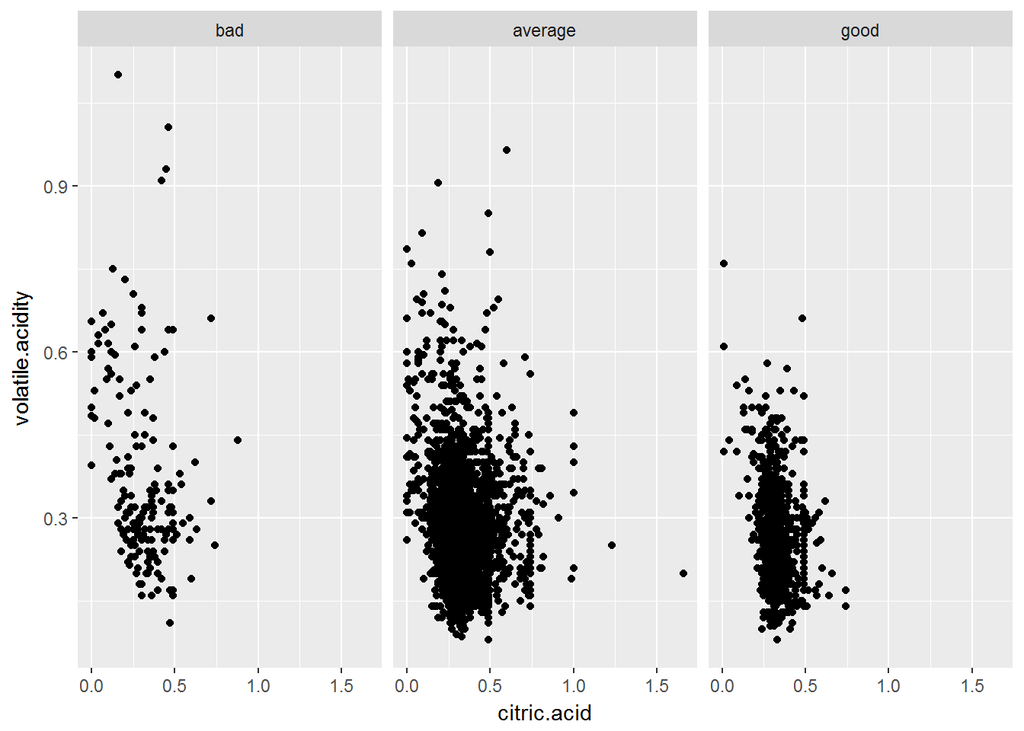

Alcohol V/s citric acid:

We can see that the plots are normally distributed in all the three categories. therefore it is the weakest bivariavte plot.

Sulfates V/S volatile.acidity:

in this case the sulfates are scattered in average wine and bad wines but are nearly normally distributed in good wines.

Sulfates V/S Citric Acid:

it is also a normal graph.

Volatile Acidity V/S Citric Acid:

It has the strongest relationship among st all. even though it has a negative correlation.

Examining the acidity variables, Since it has the best correlation:

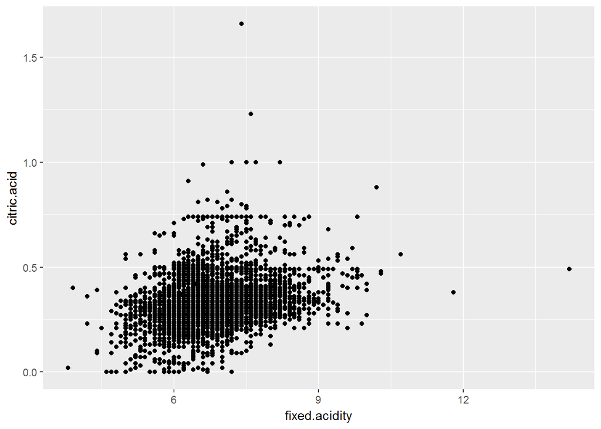

```
##
##  Pearson's product-moment correlation
##
## data:  wine$fixed.acidity and wine$citric.acid
## t = 21.137, df = 4896, p-value < 2.2e-16
## alternative hypothesis: true correlation is not equal to 0
## 95 percent confidence interval:
##  0.2633067 0.3146389
## sample estimates:
##       cor
## 0.2891807
```

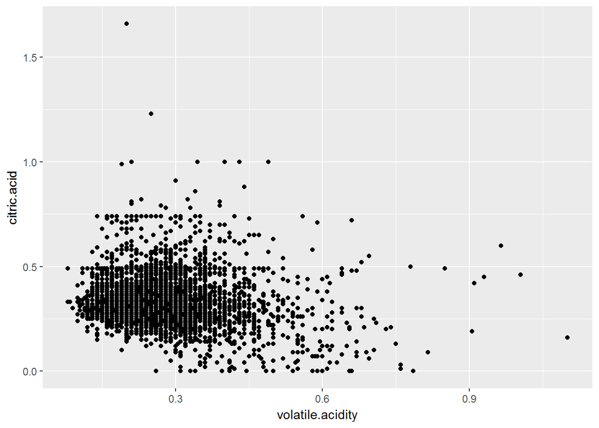

```
##
##  Pearson's product-moment correlation
##
## data:  wine$volatile.acidity and wine$citric.acid
## t = -10.578, df = 4896, p-value < 2.2e-16
## alternative hypothesis: true correlation is not equal to 0
## 95 percent confidence interval:
##  -0.1767384 -0.1219760
## sample estimates:
##        cor
## -0.1494718
```

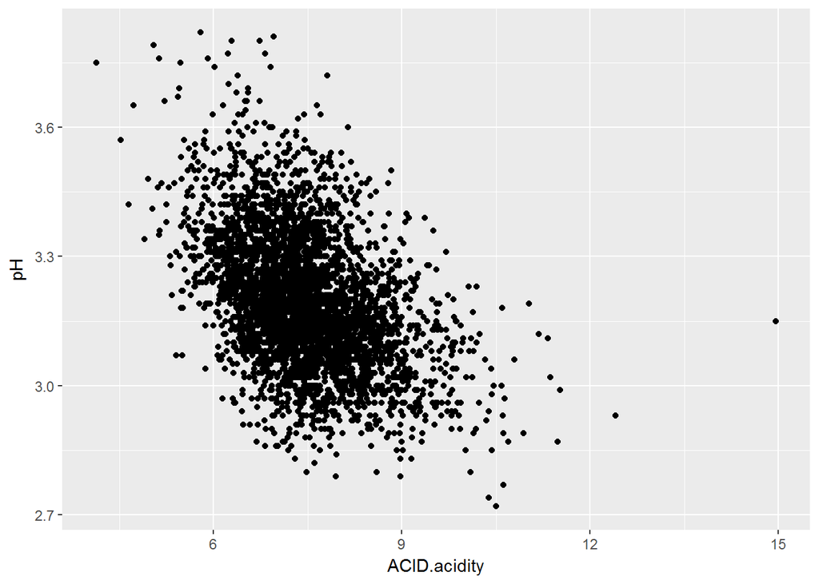

```
##
##  Pearson's product-moment correlation
##
## data:  log10(wine$ACID.acidity) and wine$pH
## t = -34.256, df = 4896, p-value < 2.2e-16
## alternative hypothesis: true correlation is not equal to 0
## 95 percent confidence interval:
##  -0.4620204 -0.4168302
## sample estimates:
##        cor
## -0.4397036
```

Here three graphs are plotted. First is the Citric Acid V/S Fixed acidity, we can observe that the acidity and citric acid is not we correlated as we can see that there are a lot of outliers. Now we will compare citric with volatile. In this case too the outliers are present. Lastly when we plot pH and Total Acidity then we can see that we are getting a strong relationship.

Since pH is a value of acidity then the relationship above is defined well, but there could be other factors which can also affect the value, therefore let us find variables affecting the pH value:

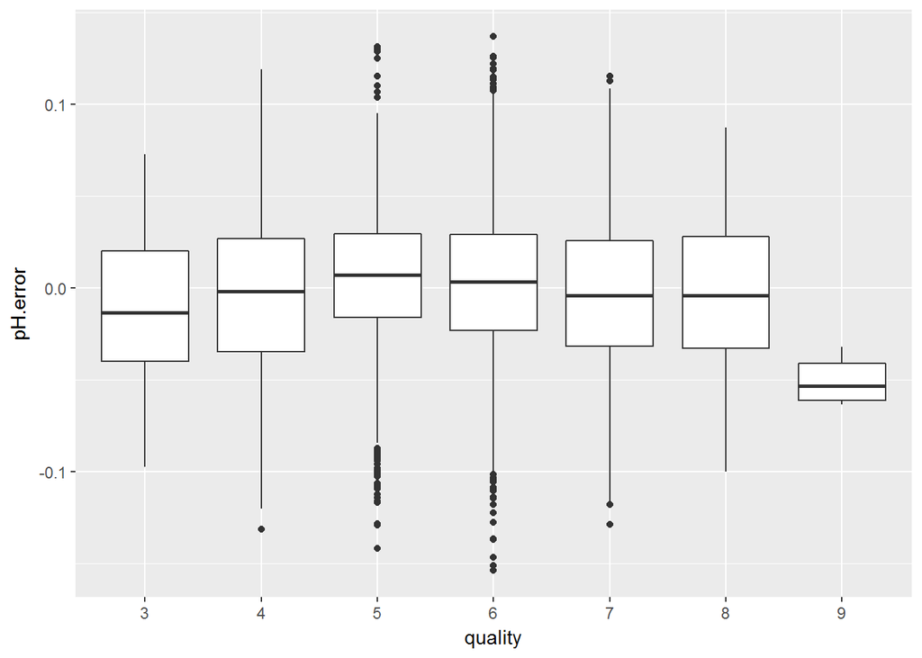

As observed from the above plot the bad wines have a lot of negative pH errors, whereas all the pH errors are in negative in the best quality wine.

as discussed before the sulfur properties are also dependent, Plotting this:

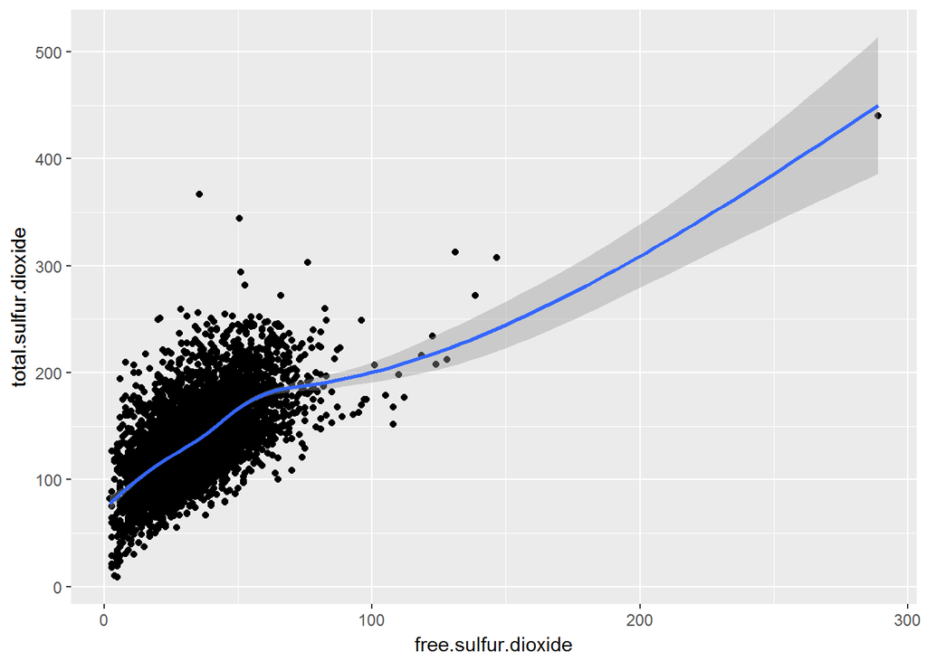

```
##
##  Pearson's product-moment correlation
##
## data:  wine$free.sulfur.dioxide and wine$total.sulfur.dioxide
## t = 54.645, df = 4896, p-value < 2.2e-16
## alternative hypothesis: true correlation is not equal to 0
## 95 percent confidence interval:
##  0.5977994 0.6326026
## sample estimates:
##      cor
## 0.615501
```

The graph shows that there is a strong relationship between total sulfur and free sulfur. The blue curve shows that as the number of sulfur quantities increases in the wines the free sulfur will also increase. This is a better bi variate variable than Acid content in wine.

# Multivariate Plots:

In this section we will be plotting multivariate plots:

Here we will compare acidity (Citric and volatile) and (alcohol and total) with quality. After this we will plot alcohol with sulfates over quality and lastly pH value with alcohol with quality..

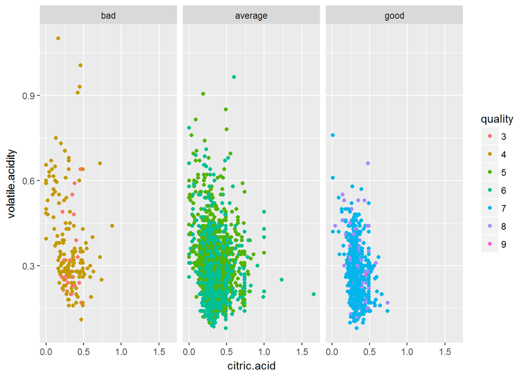

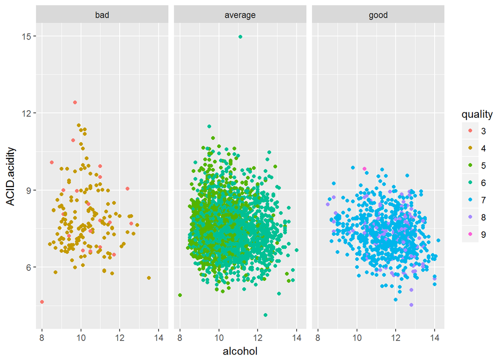

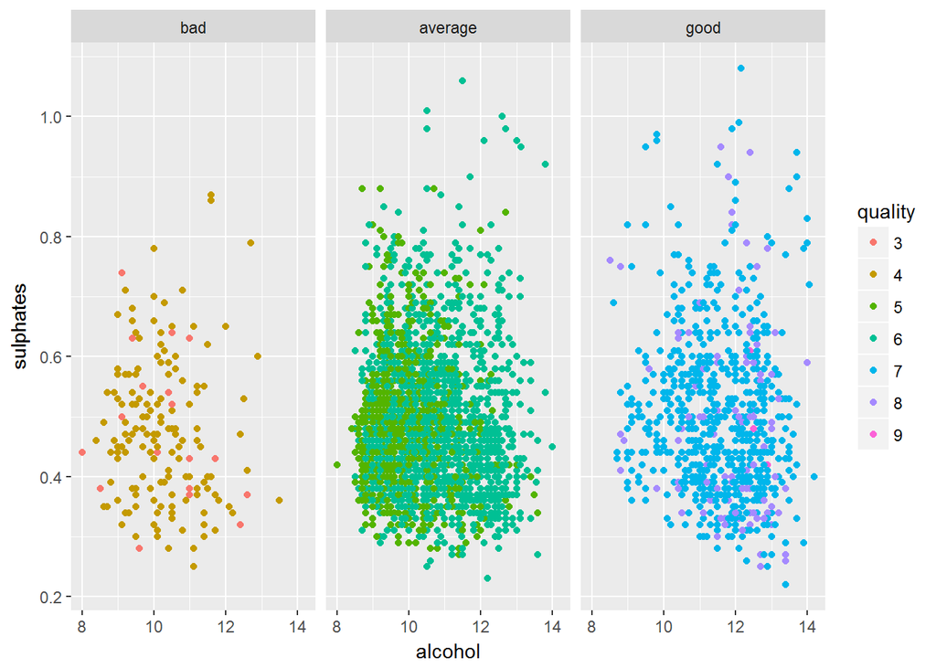

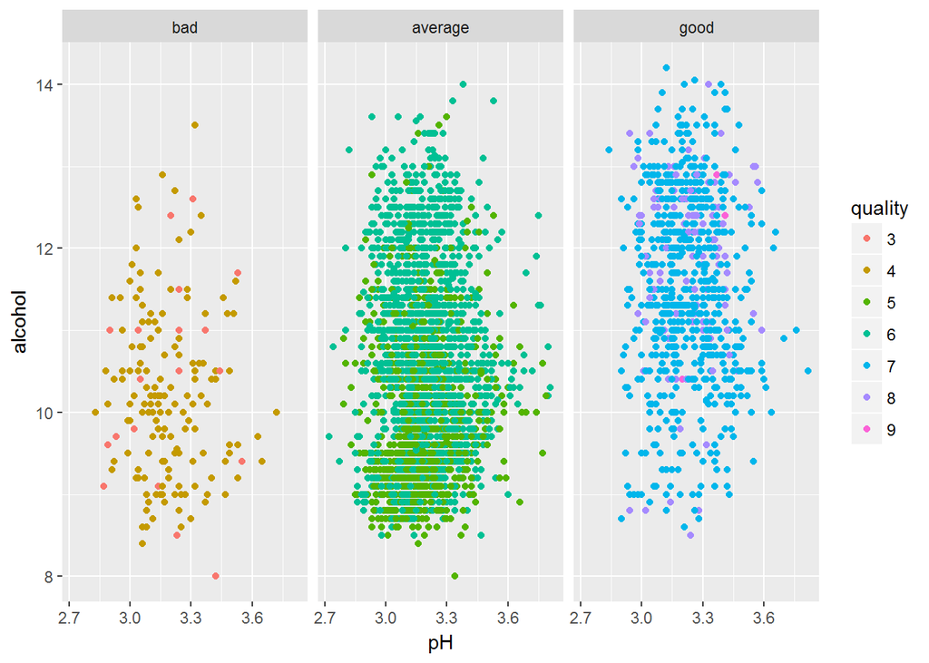

## Multivariate Analysis

# Summary

### Plot 1: Effect of acids on wine quality

To Learn the effect of acids more clearly we will plot box based on the quality as from the multivariate analysis we get that acids have major impact on the quality of wine.

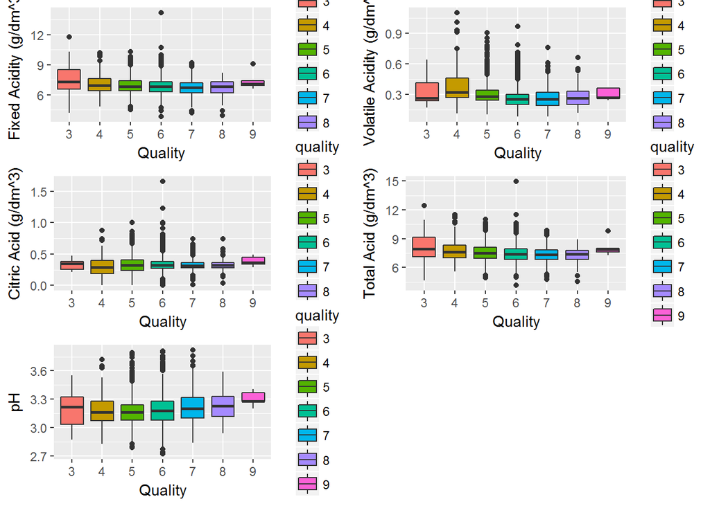

### Plot 2: Effect of Alcohol on Wine Quality:

Another variable with high correlation is the alcohol content of the which can also be seen into multivariate plots. Let us box plot the alcohol to find the range.

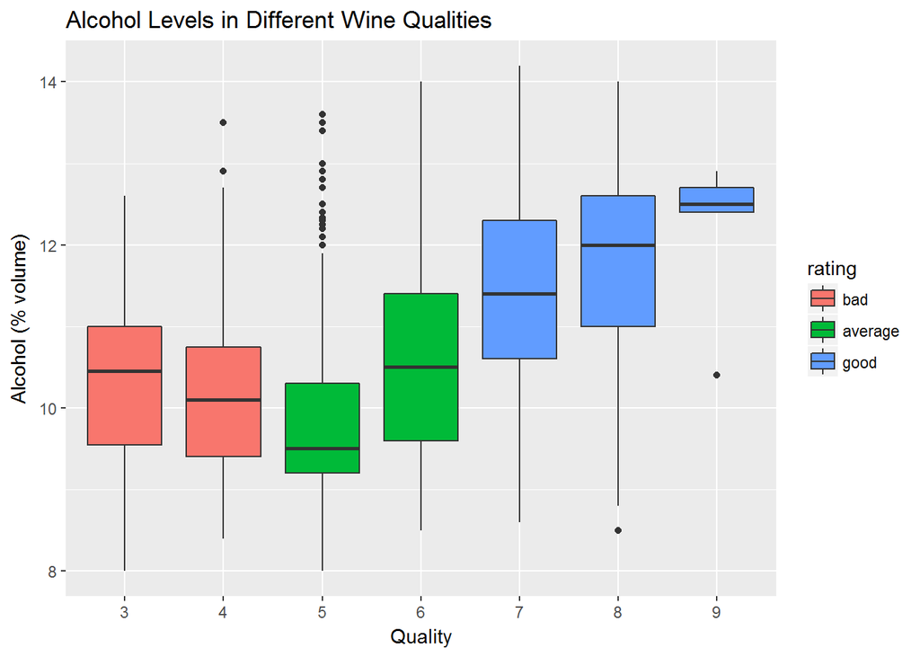

The alcohol content as from the plot we can see that a good concentration of alcohol is present in wines quality vales of 7 and above. We have alcohol content between 10 to 13.

### Plot 3: What makes good wines:

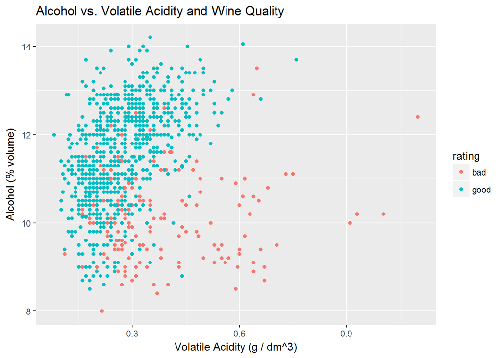

# Reflection

1. How the analysis was conducted? To find the result we first plotted all the available variables with the with the count so that we can get a proper picture of the data. From the data we found that we can categories the wine for simplifying the analysis. therefore created the Good, Average and bad wine groups. Then i found that the system was having dependent variables like acids and sulfates now i plotted the data using two variables. Correlation was calculated to find the best fit variables. Witt the help of all the plots we found that acid plays an important role in making good wines.
2. Struggles and Success throughout the analysis? There were two important struggles in the analysis, first weather to take acidity, sulfates or residual sugar into account. the decision took was the acidity which throughout was applicable. The second was to believe the correlation, as the variables with high correlation were found to be not helpful while analyzing the plots.
3. Future Work?

The work can be extended by studying how residual sugar affects the wines and does the sugar affects the acidity of the wine.

4. Important Decision in analysis? One of the important decision was to take the acidity as the variable till the last to make the analysis.

# References:

https://en.wikipedia.org/wiki/Acids_in_wine

https://en.wikipedia.org/wiki/Wine

http://www.r-tutor.com/elementary-statistics/numerical-measures/correlation-coefficient

http://stackoverflow.com/questions/3571909/calculate-correlation-cor-for-only-a-subset-of-columns

Books:

Data Analysis and Graphics using R by John Maindonald

Learning R by Richard Cotton